# 第8回 実験の注意と分析の注意

経済プログラミング特論II

第8回

実験の注意と分析の注意

前半の実験でつまずいた所を、実験の順に並べ直す

経済プログラミング特論II

第8回 — Topic01

実験計画

比べる相手と測る数を、集める前に決める

## 前半の 4 つの実験

> この回、あなたは次の実験を企画し、結果を報告する人です  
> 前半でつまずいた所から、注意の一覧を作ります

美人投票

平均の 3 分の 2 に近い数を選んだ人が勝ち  
変えた：平均と目標値を見せて 2 回目  
比べた：1 回目と 2 回目の平均

公共財

持ち点 20 のうち箱に出した分が  
1.6 倍で 4 人に戻る  
比べた：計算の答え（0）と、教室の平均

罰のルール（ABM）

平均より 4 を超えて低い人に罰を出す  
変えた：罰の有無と、罰 1 件の費用  
比べた：拠出と、罰の後に残る点

条件を 1 つずつ（ABM）

100 人の社会で、条件を 1 つだけ変える  
変えた：見せるか・誰がいるか・倍率  
比べた：10 ラウンドの平均拠出

4 つとも、比べる相手を置いて、選んだ数を読んだ

## 注意の一覧

この回で作る表。前半でつまずいた所を、実験の順に並べる

| 実験の順 | 注意 | 前半のどこで |
| --- | --- | --- |
| **集める前** | **？** | **教室の 2 回目・4 人の班の 2 つの数** |
| 集めるとき | ？ | 実験の日の約束・AI に渡した文 |
| 数えて読むとき | ？ | seed を替えた図・教室の平均 |
| 回す道具を読むとき | ？ | ABM の線・AI の答え |

上の 2 行が**実験のやり方**の注意、下の 2 行が**分析**の注意

## 今日の道のり

**今日のゴール**：次の実験を企画し報告するときの  
注意の一覧を、実験の順に 4 行つくる

1

比べる相手と測る数を  
先に決める

演習 1 計画メモの穴を選ぶ

2

同じ文・同じ手順で  
聞き、全部残す

演習 2 欠けた約束を選ぶ

3

揺れより  
大きいかで読む

演習 3 言い過ぎを選ぶ

4

代役の答えを  
確かめて使う

演習 4 AI の使い方を分ける

このトピックでは、**比べる相手と測る数**を、いつ決めるかを見る

## このトピックで学ぶこと

- **ここまで**：前半の 4 つの実験は、どれも  
  比べる相手を置いて、選んだ数を読んだ
- **でも**：教室の美人投票の 2 回目は、なぜ下がったのかを  
  あとから確かめようとしても、確かめられない
- **問い**：比べる相手と測る数は、いつ決めておけばよいか
- **見るもの**：教室の 2 回目 → 前に見た 2 つの社会  
  → 4 人の班の 2 つの数

そこで、教室の美人投票の **2 回目**から見直す

## 2 回目の平均が下がった理由

2026年度のデータ

実験の日の美人投票。1 回目の平均と目標値を見せてから  
2 回目を選ぶと、平均は 43.38 から 34.58 に下がった  
下がった理由として言えるのは

- **①** 平均を見たから
- **②** 2 回目だから
- **③** この数だけでは決められない

動画を止めて、①〜③から 1 つ選んで、少し考えてから再生

## 2 回目に重なった 2 つの違い

2026年度のデータ

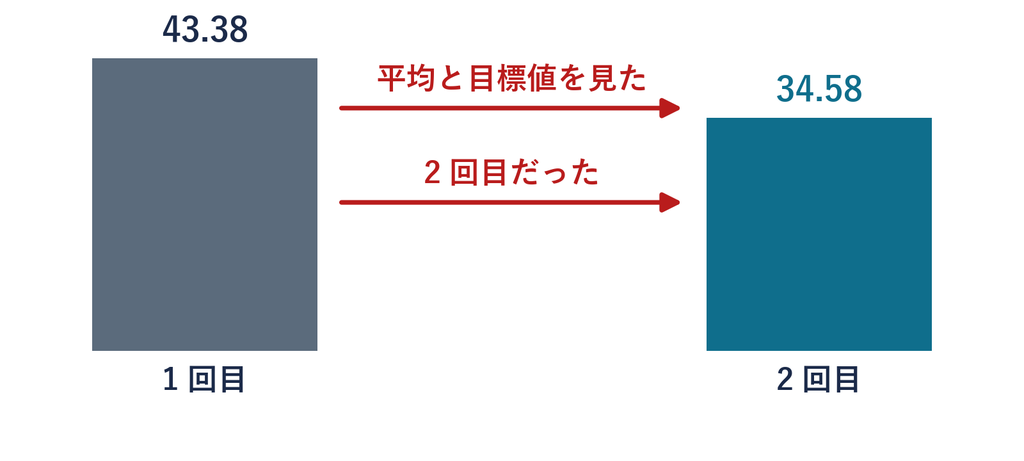

見なかった組が無いので、どちらのせいかは分けられない（答えは ③）

## 見なかった組の作り方

2026年度のデータ

同じ日は、もう人ではやり直せない。前に見たように、公共財では  
ABM で平均を見せない社会を作り、比べる相手にした

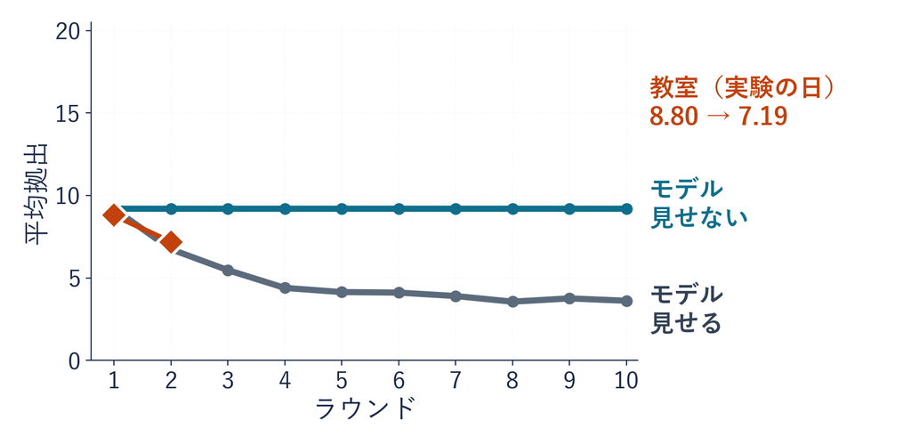

モデル10 ラウンドの平均拠出は、見せる 4.89 ／ 見せない 9.20  
seed を 10 通り変えても、10 本とも見せないほうが上

教室平均 8.80 を見せた後の 2 回目は 7.19（合うのは下がる向きまで）

## 入れ替えの相手

前に見た、ただ乗りの人数を変えた社会。100 人のままなので  
増やした分は、どこかの人数を減らすしかない

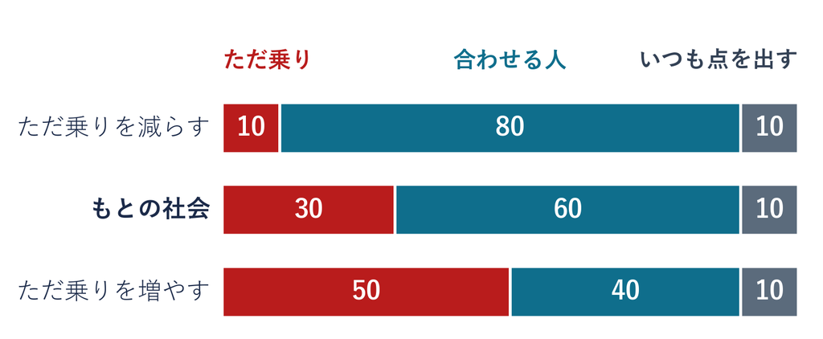

何と入れ替えたかまで決めて  
初めて「1 つだけ変えた」と言える

## 測る数の替え方と結論

拠出：箱に出した点（班の平均）

純利得：罰で消えた点を引いた後の、一人あたりの受け取り

同じ 4 人の班・同じ比較（罰なし → 罰あり）で、測る数を  
拠出から純利得に替えると、「罰は成功」という結論は

- **①** 同じ
- **②** 逆になることがある
- **③** 必ず逆

動画を止めて、①〜③から 1 つ選んで、少し考えてから再生

## 4 人の班の拠出

まず 4 人で、手で追う。前に出てきた班  
（A いつも 0・B と C は合わせる・D いつも 20）  
3 ラウンド・組み直さない。罰ありは、  
罰を受けた人が次から出す点を変える。罰 1 件の費用は 1 と 25

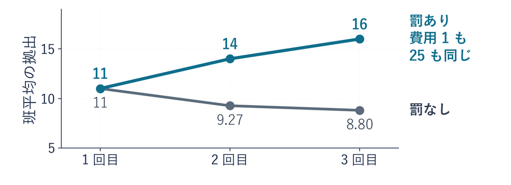

1 ラウンド目A 0・B 12・C 12・D 20 → 44 ÷ 4 ＝ 11

罰なし11 → 9.27 → 8.80（3 ラウンドの平均 9.69）

罰あり11 → 14 → 16（平均 13.67）。費用 1 でも 25 でも同じ

拠出の差13.67 − 9.69 ＝ +3.98 で、拠出で測ると罰は成功に見える

## 4 人の班の純利得

同じ班・同じ比較を、純利得（罰で消えた点を引いた後の一人あたりの受け取り）で測る

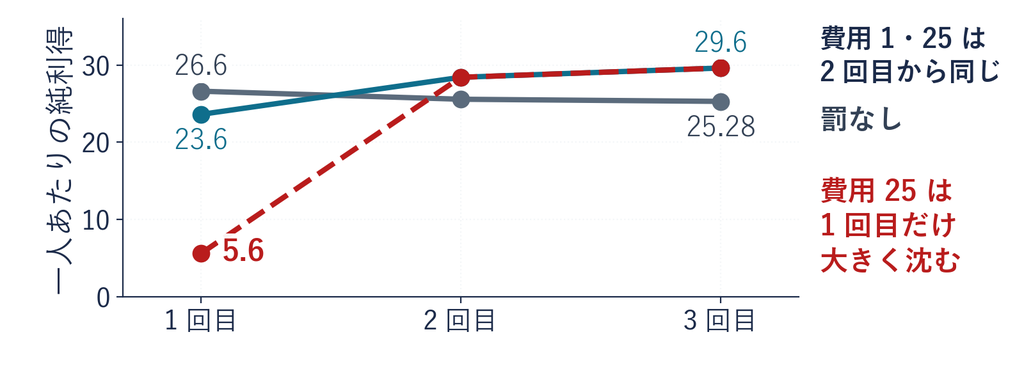

費用 1平均 27.2 で、罰なし 25.81 との差 +1.39

費用 25平均 21.2 で、差 −4.61（1 ラウンド目に罰 3 件で 5.6 まで沈む）

純利得で測ると、費用 25 では罰で皆が損  
同じ班なのに、結論が逆（答えは ②）

## よくある失敗 測る数の後出し

**測る数を後から選ぶと、結論も選べてしまう**

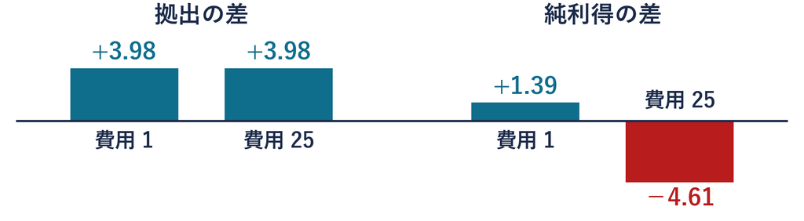

✕ 回してから選ぶ

差が分かりやすい数で書く  
拠出なら「成功」、純利得なら「皆が損」

○ 回す前に書く

測る数を先に決めて残す  
予想と逆でも、決めた数で書く

## 実験計画

**比べる相手と測る数を、集める前に決めておくこと**

定義

**実験計画**基準条件・操作する条件・評価量を  
データを集める前に定めたもの

**事前登録**研究の問い・評価量・予想を  
データを集める前に記録して残すこと

基準条件は比べる相手、評価量は測る数のこと

- **例**：見せる組と見せない組を作り、2 回目の平均で比べると先に書く
- **動き方**：比べる相手は、集めた後からは作れない  
  測る数は、後から選ぶと結論が選べる

## 演習1 計画メモの穴

演習 1

3 つの計画メモのうち、注意を破っているのはどれか

- **①** 見せる組だけ集め、2 回目が下がったら「見せたせい」と書く
- **②** 拠出と純利得を両方回してから、差がいちばん大きい数で書く
- **③** 見せる組と見せない組を作り、拠出の平均で比べると  
  集める前に書いておく
1. **選ぶ**：注意を破っているメモの番号を、全部
2. **書く**：`lecture08_report.ipynb` の演習 1 の答え欄に  
   番号と、破った注意を 1 文

⏸ PAUSE 動画を止めて $3$ 分。番号と 1 文を書いたら再生に戻る

## 演習1の答えとまとめ

- **①**：見せない組が無い。比べる相手を、集める前に用意していない
- **②**：測る数を、結果を見てから選んでいる
- **③**：比べる相手と測る数を、集める前に決めている（守っている）

| 実験の順 | 注意 | 前半のどこで |
| --- | --- | --- |
| **集める前** | 比べる相手と測る数を、 集める前に決めておく | **教室の 2 回目・4 人の班の 2 つの数** |
| 集めるとき | ？ | 実験の日の約束・AI に渡した文 |
| 数えて読むとき | ？ | seed を替えた図・教室の平均 |
| 回す道具を読むとき | ？ | ABM の線・AI の答え |

分かったこと：比べる相手と測る数は、集める前に決める  
残った問い：決めた比較でも、聞き方や順番が違えば、差はそこから出るのでは  
これを次のトピックで見る

経済プログラミング特論II

第8回 — Topic02

実験手続きの統一と記録

同じ文・同じ手順で聞き、全部残す

## 今日の道のり

**今日のゴール**：次の実験を企画し報告するときの  
注意の一覧を、実験の順に 4 行つくる

1

比べる相手と測る数を  
先に決める

演習 1 計画メモの穴を選ぶ

2

同じ文・同じ手順で  
聞き、全部残す

演習 2 欠けた約束を選ぶ

3

揺れより  
大きいかで読む

演習 3 言い過ぎを選ぶ

4

代役の答えを  
確かめて使う

演習 4 AI の使い方を分ける

このトピックでは、比べる相手に**何を同じにし、何を残すか**を見る

## お金がもらえたら

前のトピックの問い：決めた比較でも、聞き方や順番が違えば  
差はそこから出るのでは

たとえば実験の日の公共財で、得点に応じてお金がもらえたとしたら  
あなたが箱に入れた数は

- **①** 増える
- **②** 同じ
- **③** 減る

動画を止めて、①〜③から 1 つ選んで、少し考えてから再生

## 実験の日の約束

約束：集める前に決めた手順。どの人にも、同じ手順で答えてもらった

|  | 約束 | 名前 |
| --- | --- | --- |
| ① | 得点は、成績にもお金にも関係しない | **インセンティブ** |
| ② | フォームは匿名（名前もメールも集めない） | **倫理と同意** |
| ③ | 数を入れる前に、ルールの理解確認 | **教示と理解確認** |
| ④ | 全員が同じフォーム・同じ説明 | **手順の統一** |
| ⑤ | 1 回目を封印してから、平均を見せて 2 回目 | **順序の効果** |

5 つとも、比べる条件のほかを、全員でそろえるための約束

## 謝礼と被験者

2026年度のデータ

謝礼：お金をどう払うか

教室では、お金を払っていない  
公共財の 8.80 は「**お金がかからない場の数**」

被験者：誰の数か

美人投票の 1 回目は、答えた区分で分ける  
分かるのは「**大学生のこの教室なら**」

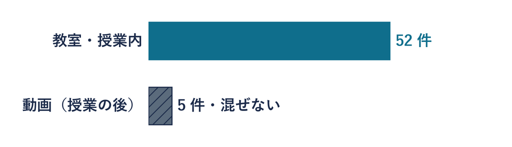

比べる 2 つの組では、払い方も、答えた人の区分もそろえる

## 1 回目と 2 回目の結び方

2026年度のデータ

美人投票のフォームは匿名。同じ人の 1 回目と 2 回目を結ぶために  
2 回目のフォームで「1 回目に入れた数」を書いてもらった

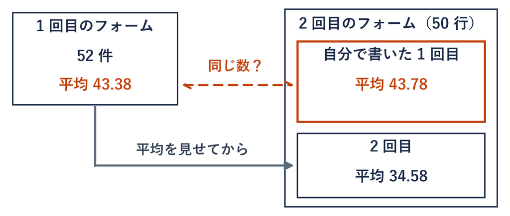

人の集まりも、数の出どころも違う  
どう結ぶかは、集める前に決めて書いておく

## 4 人組の組み方

2026年度のデータ

公共財の 4 人組は、授業の後に組んだ。並べ替えを決める番号（seed）は  
データを見る前に決めて、書き残した

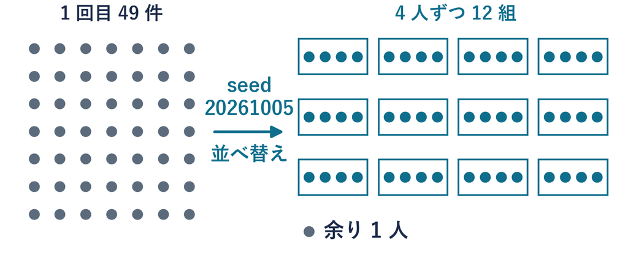

決め方が残っているので、後から誰が組み直しても同じ 12 組

## AI に渡した文

保存ログ：教員が前もって 2 つの AI に公共財の問いを聞き  
答えを残した記録（同じ文で 20 回ずつ）

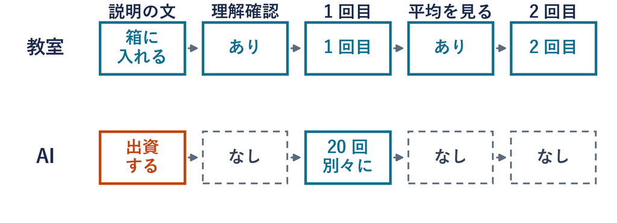

文教室は「共同の箱に入れる」、AI は「共同プロジェクトに出資」

順AI には、理解確認も、平均を見せた 2 回目もない

人と比べるなら、人と同じ文・同じ順で聞く

## 記録すること

| 記録すること | 紙・フォーム | ABM（Python） | AI |
| --- | --- | --- | --- |
| **条件** | 教示の文・順番 | ルールと設定 | 答え方の指定 |
| **回数** | 人数・ラウンド | seed の本数 | 聞いた回数 |
| **入力の全文** | フォームの文 | コード | 渡した文 |
| **名前と日付** | 集めた日 | Python の版 | モデル名・日付 |
| **確かめたこと** | 理解確認の結果 | 本文の数との照合 | 0〜20 の数か |

差が出たときに、どこが違ったかを後から確かめるため

道具が変わっても、記録することは同じ

## 手続きの統一と記録

比べる相手に、同じ文・同じ手順で聞き  
聞いたことを全部残すこと

定義

**統制**比較する条件以外の教示・手順・謝礼を  
すべての条件で同一にすること

**記録**教示の全文・手順・回数・実施日を  
第三者が再現できる形で残すこと

統制は「同じ文・同じ手順で聞く」、記録は「全部残す」

- **例**：AI にも教室と同じ文・同じ順で聞き、渡した文と日付を残す
- **動き方**：ほかが同じなら、差は変えた条件から出たと言える  
  残しておけば、同じでなかった所を後から確かめられる

## 演習2 報告に欠けた約束

演習 2

3 つの報告に欠けている約束は、表のどれか

- **A** 比べる 2 つの組のうち、片方の組にだけ、得点に応じてお金を払った
- **B** AI には理解確認も付けて「共同プロジェクトに出資」の文で聞き  
  教室の 1 回目の平均と比べた
- **C** 平均を見せた後で、1 回目の数を書き直してもよいことにした

① インセンティブ ② 倫理と同意 ③ 教示と理解確認  
④ 手順の統一 ⑤ 順序の効果

1. **選ぶ**：報告ごとに、欠けている約束の番号を 1 つ
2. **書く**：`lecture08_report.ipynb` の演習 2 の答え欄に  
   A・B・C の番号と、理由を 1 文

⏸ PAUSE 動画を止めて $3$ 分。番号と理由を書いたら再生に戻る

## 演習2の答えとまとめ

- **A**：① インセンティブ。差が、変えた条件からでなくお金から出る
- **B**：④ 手順の統一。文が違うので、差が文から出る
- **C**：⑤ 順序の効果。1 回目が、平均を見た後の数に変わる

| 実験の順 | 注意 | 前半のどこで |
| --- | --- | --- |
| 集める前 | 比べる相手と測る数を、 集める前に決めておく | 教室の 2 回目・4 人の班の 2 つの数 |
| **集めるとき** | 比べる相手に、 同じ文・同じ手順で聞き、 聞いたことを全部残す | **実験の日の約束・AI に渡した文** |
| 数えて読むとき | ？ | seed を替えた図・教室の平均 |
| 回す道具を読むとき | ？ | ABM の線・AI の答え |

分かったこと：比べる相手には、同じ文・同じ手順で聞き、全部残す  
残った問い：そろえて集めた数でも、数え方で結論が変わるのでは  
これを次のトピックで見る

経済プログラミング特論II

第8回 — Topic03

頑健性

1 本・平均だけで決めず、揺れより大きいかで読む

## 今日の道のり

**今日のゴール**：次の実験を企画し報告するときの  
注意の一覧を、実験の順に 4 行つくる

1

比べる相手と測る数を  
先に決める

演習 1 計画メモの穴を選ぶ

2

同じ文・同じ手順で  
聞き、全部残す

演習 2 欠けた約束を選ぶ

3

揺れより  
大きいかで読む

演習 3 言い過ぎを選ぶ

4

代役の答えを  
確かめて使う

演習 4 AI の使い方を分ける

このトピックでは、差が**揺れより大きいか**で読むことを見る

## 平均が下がったら

前のトピックの問い：そろえて集めた数でも  
数え方で結論が変わるのでは

教室の美人投票で、同じ 50 人の平均は  
1 回目 43.78 → 2 回目 34.58 と下がった。数を上げた人は

- **①** いない
- **②** 数人
- **③** 3 割くらい

動画を止めて、①〜③から 1 つ選んで、少し考えてから再生

## 平均の動きと一人ひとりの動き

2026年度のデータ

前に見た、同じ 50 人の 1 回目と 2 回目を、1 人 1 本の線でつなぐと

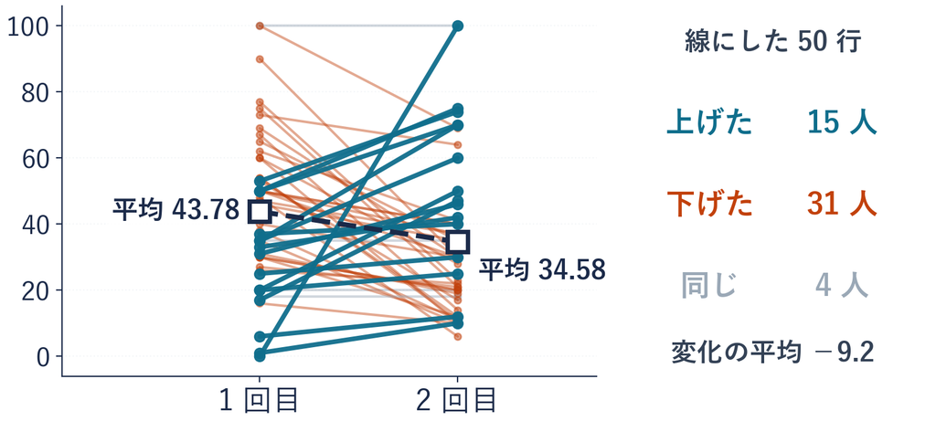

平均は下がったのに、15 人（3 割）は上げた（答えは ③）  
平均 1 つは、一人ひとりの動きを隠す

## 1 本だけ選んだ図

前に出てきた 100 人の社会（罰 1 件の費用は 25）で、seed 1000〜1004 の  
5 本から 1 本だけ選び、純利得の差（罰あり − 罰なし）を図にすると

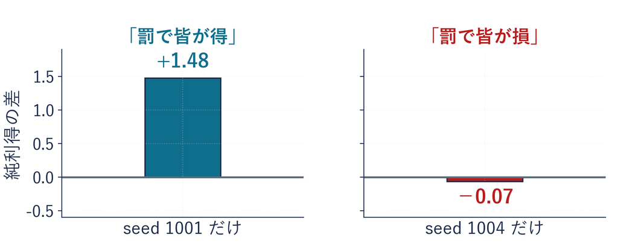

同じモデル・同じ費用 25 なのに、選んだ 1 本で結論が逆

## 20 本の純利得の差

今度は 20 本で（費用 25・seed 1000〜1019 を全部）

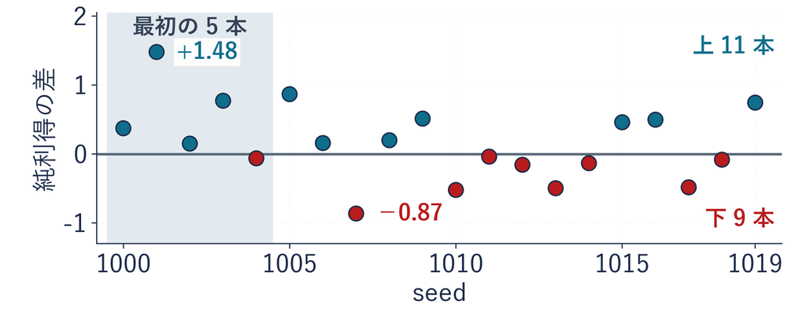

上と下上 11 本・下 9 本

平均+0.17

範囲最小 −0.87（seed 1007）〜最大 +1.48（seed 1001）

seed を替えても結論が変わらないか  
決めた本数を全部、範囲で書く

## デモ 揺れと差の大きさ

数の話

純利得の差 ＝ 罰ありの純利得 − 罰なしの純利得

- **何を見るか**：seed 20本それぞれの、一人・一ラウンドの差（費用25）
- **図の意味**：横＝seed・縦＝差・破線＝20本の平均
- **操作**：1本／20本・前後の seed・測る数の切り替え

ミッション 符号が逆になる seed を2本見つける

※ 次のスライドへ進むときは、デモの枠の外を一度クリックしてから ← → キーを押す

[interactive chart not shown]

## 揺れと差の大きさ

揺れ：同じ条件のまま、seed や集め直しを替えたときの数の動き  
前に見たように、見せる社会と見せない社会は、seed を 10 通り替えても見せないほうが上だった

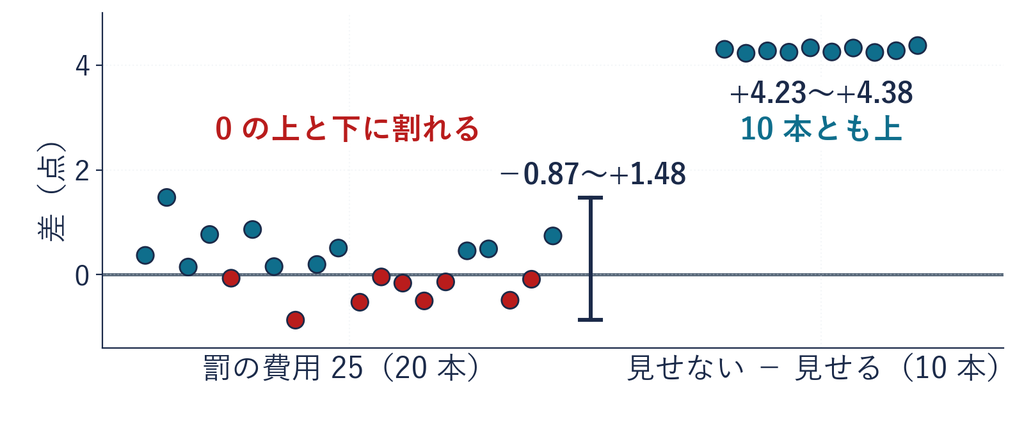

罰の費用 25差 −0.87〜+1.48 で 0 をまたぐ。向きは言えない

見せない − 見せる差 +4.23〜+4.38 で 10 本とも上。向きが言える

差が揺れより大きく  
どの本でも同じ向きなら、結論が言える

## 4 人の班の予想と結果

最初のトピックの 4 人の班で、回す前にこう予想して書いておいたとする  
予想：罰 1 件の費用を 1 から 25 に上げると、罰が減り、拠出も減る

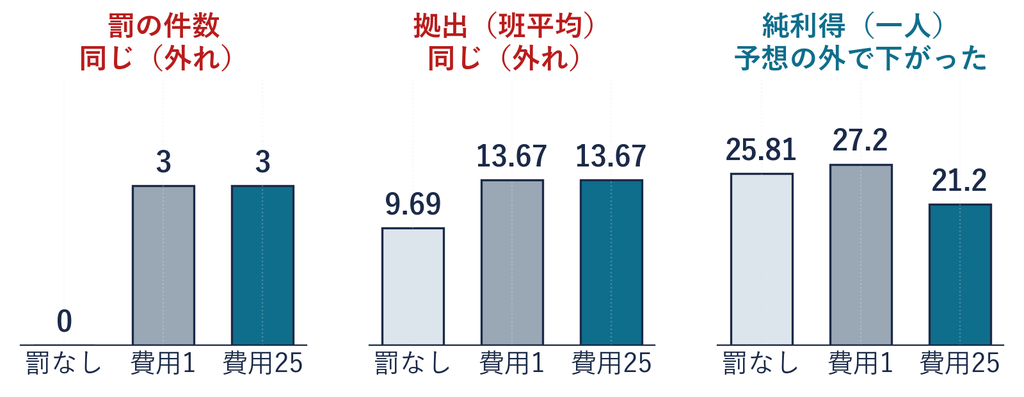

予想した 2 つ罰は 3 件、拠出は 13.67 のまま。2 つとも外れ

予想の外純利得が 27.2 → 21.2 に下がった（罰なしは 25.81）

外れた予想も、予想の外で動いた数も、消さずに全部載せる

## 頑健性

seed や集め直しを替えても  
結論が同じ向きに出ること

定義

**頑健性**乱数の種・標本・設定を替えて分析し直しても  
結論の向きが変わらないこと

乱数の種は seed、標本を替えるとは同じ実験を別の人で集め直すこと

- **例**：見せない社会と見せる社会の差は、10 本とも上で頑健  
  費用 25 の罰の差は、上 11・下 9 で頑健でない
- **動き方**：決めた本数を全部並べ、差が揺れより大きく  
  どの本でも同じ向きかを見る

## 演習3 報告の言い過ぎ

演習 3

3 つの報告は、言える範囲か、言い過ぎか

- **A** seed 1001 の 1 本を図にして「費用 25 でも、罰で皆が得をする」と書いた
- **B** seed 1000〜1019 の 20 本を全部並べ「上 11 本・下 9 本で、向きは決まらない」と書いた
- **C** 美人投票の平均が 43.78 → 34.58 に下がったので「全員が数を下げた」と書いた

① 言える範囲 ② 言い過ぎ

1. **選ぶ**：報告ごとに、① か ② を 1 つ
2. **書く**：`lecture08_report.ipynb` の演習 3 の答え欄に  
   A・B・C の番号と、言い過ぎにした報告ごとに理由を 1 文

⏸ PAUSE 動画を止めて $3$ 分。番号と理由を書いたら再生に戻る

## 演習3の答えとまとめ

- **A**：② 言い過ぎ。20 本のうち 9 本は下だった
- **B**：① 言える範囲。決めた本数を全部、範囲で書いた
- **C**：② 言い過ぎ。50 人のうち 15 人は上げていた

| 実験の順 | 注意 | 前半のどこで |
| --- | --- | --- |
| 集める前 | 比べる相手と測る数を、 集める前に決めておく | 教室の 2 回目・4 人の班の 2 つの数 |
| 集めるとき | 比べる相手に、 同じ文・同じ手順で聞き、 聞いたことを全部残す | 実験の日の約束・AI に渡した文 |
| **数えて読むとき** | seed や集め直しを替えても、 結論が同じ向きに出るかを見る | **seed を替えた図・教室の平均** |
| 回す道具を読むとき | ？ | ABM の線・AI の答え |

分かったこと：差は、揺れより大きく、どの本でも同じ向きかで読む  
残った問い：何度でも回せる代役（ABM・AI）の数なら  
そのまま人の答えとして書けるのでは。これを次のトピックで見る

経済プログラミング特論II

第8回 — Topic04

モデルと AI の解釈

代役の答えは、書いたルールと渡した文の結果

## 今日の道のり

**今日のゴール**：次の実験を企画し報告するときの  
注意の一覧を、実験の順に 4 行つくる

1

比べる相手と測る数を  
先に決める

演習 1 計画メモの穴を選ぶ

2

同じ文・同じ手順で  
聞き、全部残す

演習 2 欠けた約束を選ぶ

3

揺れより  
大きいかで読む

演習 3 言い過ぎを選ぶ

4

代役の答えを  
確かめて使う

演習 4 AI の使い方を分ける

このトピックでは、**代役の答え**を、どこまで人の答えとして書けるかを見る

## 合った線の読み方

前のトピックの問い：何度でも回せる代役（ABM・AI）の数なら  
そのまま人の答えとして書けるのでは

前に、教室の美人投票の 2 回目の平均 34.58 に  
ABM の線を合わせ、合う人数比の組を見つけた  
この組で、教室の人がそう考えたと言えるか

- **①** 言える
- **②** 言えない
- **③** 平均だけでは決められない

動画を止めて、①〜③から 1 つ選んで、少し考えてから再生

## 合わせた数と確かめた数

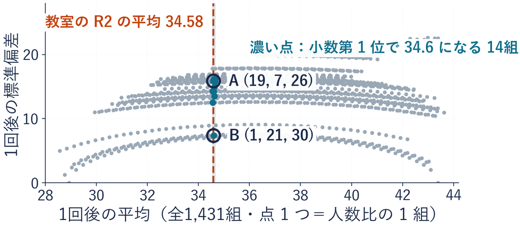

合わせた数2 回目の平均 34.58 → 1,431 組のうち 14 組が合う

確かめた数2 回目の標準偏差 22.95 → 14 組の最大は 16.17 で、どれも届かない

1 つの数に合わせたら、合わせていない数で確かめる（入口の答えは ③）

## ルールに書いていない反応

前に見た 100 人の社会：倍率だけを 1.6・2.4・3.2 に（10 ラウンド）

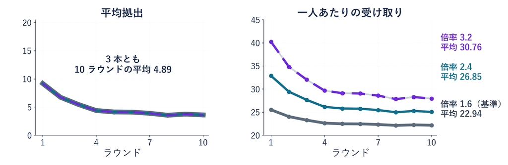

拠出3 本とも 10 ラウンドの平均 4.89 のまま

受け取り22.94・26.85・30.76 と、倍率で上がる

合わせる人のルールに、倍率が書いていない。だから拠出は動かない

## AI に聞いたことと、2 つの使い方

前に出てきた保存ログ：GPT と Claude に、同じ文で 20 回ずつ聞いた記録

**聞いた文**：4 人の班で、全員が 20 点ずつ持つ。0〜20 点を共同プロジェクトに出資できる  
出資の合計は 1.6 倍になり、4 人で等しく分ける。何点出資するか、理由 1 文と数 1 つで答える  
**役割の一文**：文の頭に付けた版も聞いた（例「あなたはお人好しの学生です。…」）  
役割は、合理的経済人・世間体を気にする人・お人好しの学生・損して得取れの商人の 4 つ

使い方 1人の代わり：AI の答えの数を、人の答えとして読めるか

使い方 2分析の助手：AI が書いた理由の文を、確かめて使えるか

## 役割の一文と AI の答え

前に出てきた AI の保存ログ（GPT と Claude に同じ文を 20 回ずつ）：入れた点の平均

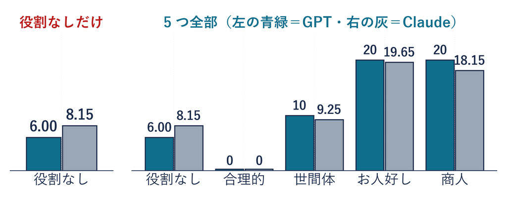

役割の一文でGPT の平均は 6.00 から、0・10・20・20 に動く

読み方人の性格の代わりではなく、役を演じた答え（ロールプレイ）

条件として試すならABM の側に、ルールとして書く

## デモ 代役の答えの読み方

理由の候補

①変えた条件が、行動ルールに入っていない  
②別の条件が、答えをほぼ決めていた  
③回数が少なく、数回の答えで平均が動く

- **何を見るか**：AI の保存ログ（役割・回数）と、公共財の20本（費用25）の3つの例
- **図の意味**：棒＝AI の平均（役割ごとの GPT と Claude）  
  点＝公共財の seed 1本の純利得の差（青緑＝上・赤＝下）・最下段に候補の ○✕
- **操作**：例の切り替え・「役割なしだけ表示」・「罰の件数で並べ替える」・候補①〜③

ミッション AI の例で「役割なしだけ表示」を押し  
GPT と Claude の上下が入れ替わるかを見る

※ 次のスライドへ進むときは、デモの枠の外を一度クリックしてから ← → キーを押す

[interactive chart not shown]

## 1 文の主張への分け方

AI を助手に。前に出てきた保存ログの、Claude・役割なし・10 回目（15 点を入れた）

> グループ全体の利益と個人の利益をバランスさせるため。  
> 全員が協力すれば**各自80点**を得られますが、相談できない不確実性下では、  
> 自分の**約75%**を出資することで協力姿勢を示しつつリスクヘッジします。

主張 1全員 20 点なら、各自 80 点  
→ 箱 80 × 1.6 ÷ 4 ＝ 一人 32（80 は箱の合計）：**誤り**

主張 215 点は、持ち点の約 75%  
→ 15 ÷ 20 ＝ 0.75：**正しい**

主張でない所「バランスさせるため」「リスクヘッジ」は、数で確かめられない

## 主張の検証

**使ってよいのは、自分のコードの数で確かめた主張だけ**

定義

**主張**説明の中の、数で確かめられる 1 文（「各自 80 点を得られる」）

**主張の検証**主張を 1 つ選び、自分のコードで数えて  
判定と根拠の数を書くこと

**判定**正しい・誤り・一部正しい の 3 つから 1 つ

1 文の中に正しい所と誤りが混ざるので、判定を 3 つにした（そう決めた）  
AI を有効に使えるのは、確かめる仕組みと一緒のとき

## 観測・仕組み・限界の区別

**結果と理由と限界を、別の文で書く**

定義

**観測**条件 A と B を比べて、測る数がどう違ったか（数で書く）

**仕組み（メカニズム）**このモデルで何を固定し、何を変えたから  
その違いが出たか

**限界**仮定を変えたときや現実の人について、まだ確かめていないこと

観測倍率を 1.6 から 3.2 にしても、拠出の平均は 4.89 のまま

仕組み合わせる人のルールに、倍率が書いていない

限界人が倍率を見て出す量を変えるかは、まだ確かめていない

## モデルと AI の解釈

代役の答えを、書いたルールと  
渡した文の結果として読むこと

定義

**代役**人の代わりに何度でも回せるモデル（ABM）や AI

**ロールプレイ**役割の一文に合わせて、AI がその役を演じた答え

- **例**：倍率で拠出が動かないのは、ルールに倍率が無いから  
  GPT が 0 から 20 まで動くのは、役割の一文が違うから
- **動き方**：答えの出どころをルールと文までたどり  
  「このルール・この文なら」まで書く

## 演習4 AI の使い方

演習 4

4 つの AI の使い方は、確かめれば使えるか

- **A** 教室と同じ文・同じ順で AI に 20 回聞き、人の数と並べる
- **B** 役割の一文を替えた AI の平均を、人の性格の違いとして報告する
- **C** AI が書いたコードの説明を、自分で回した数で確かめて使う
- **D** AI に 1 回だけ聞いた答えを、AI の答えとして載せる

① 確かめれば使える ② 人の代わりにしている・確かめていない

1. **選ぶ**：A〜D に、① か ② を 1 つずつ
2. **書く**：`lecture08_report.ipynb` の演習 4 の答え欄に番号と  
   A〜D から 1 つ選び、そこで記録することを 1 つ（記録の表は p.26）

⏸ PAUSE 動画を止めて $3$ 分。番号と記録することを書いたら再生に戻る

## 演習4の答え

- **A**：① 確かめれば使える。同じ文・同じ順で聞き、人と並べる
- **B**：② 人の代わりにしている。役割の一文で動いた数だった
- **C**：① 確かめれば使える。説明を、自分の数で確かめた
- **D**：② 確かめていない。1 回では、聞き直したときの揺れが分からない

記録の例（A）：渡した文の全文・モデル名と日付・聞いた回数 20

| 実験の順 | 注意 | 前半のどこで |
| --- | --- | --- |
| 集める前 | 比べる相手と測る数を、 集める前に決めておく | 教室の 2 回目・4 人の班の 2 つの数 |
| 集めるとき | 比べる相手に、 同じ文・同じ手順で聞き、 聞いたことを全部残す | 実験の日の約束・AI に渡した文 |
| 数えて読むとき | seed や集め直しを替えても、 結論が同じ向きに出るかを見る | seed を替えた図・教室の平均 |
| **回す道具を読むとき** | 代役の答えを、書いたルールと渡した文 の結果として読む | **倍率・役割の一文・各自 80 点** |

## 報告の 6 段と注意の一覧

|  | 段 | 書くこと | 注意の一覧の行 |
| --- | --- | --- | --- |
| 1 | **問い** | X を変えると、Y はどう変わるか | 集める前（比べる相手） |
| 2 | **仮説** | 向きと理由の予想 | 集める前（先に書いて残す） |
| 3 | **設計** | そろえたもの・変えた条件・測る数・seed | 集める前・集めるとき |
| 4 | **結果** | 比べた数を、外れた所も全部 | 数えて読むとき |
| 5 | **頑健性** | seed を替えても、同じ向きか | 数えて読むとき |
| 6 | **限界** | まだ確かめていないこと | 回す道具を読むとき |

分かったこと：前半でつまずいた所が、注意の一覧の 4 行になった  
報告では、6 段のどの段に書くかが決まっている  
この先：実験のパートはここでひと区切り。店を始めた学生の相談に乗り  
同じシミュレーションと、同じ注意を使う  
やること：演習 1〜4 の答え欄を書いて、いつもの手順で提出